# Pakiet SuperFarmerDA - wyniki

Dominik Ambroziak, Przemysław Dycha

31 grudnia 2016

## Czas gry strategii z pakietu SuperFarmerDA

Poniżej zostało przedstawione działanie strategii wbudowanych wewnątrz pakietu `SuperFarmerDA`.

Wynikiem funkcji `badaj_gre` jest lista z trzema elementami. W poniższych wykonaniach używamy przypisania, by każdy z elementów wyniku wyświetlić osobno.

### strategia_maxrabbit

Jest to najlepsza nasza startegia.

```r
lista <- badaj_gre(strategia_maxrabbit, 10000)
x<- c()
x[1]<-mean(lista[[1]])

head(lista[[1]], 10)
```

```
##  [1]  37 103  38  58 136  25  37  58  35  14
```

```r
lista[[2]]
```

```
##    Min. 1st Qu.  Median    Mean 3rd Qu.    Max.
##    9.00   26.00   35.00   39.87   49.00  177.00
```

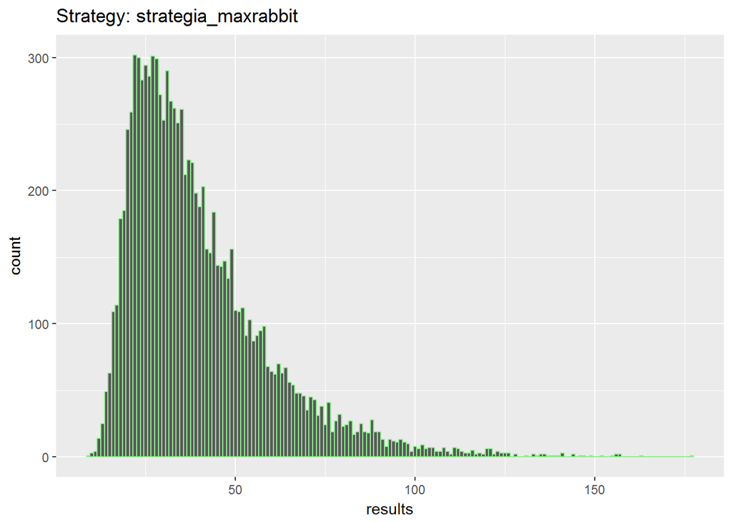

```r
lista[[3]]
```

Dalej są wyświetlane już tylko podstawowe statystyki (drugi element wynikowej listy).

#### strategia_PDMS

Strategia_PDMS jest strategią zaprojektowaną we wcześniejszej fazie projektu, w której zachodzi wymienianie wielu zwierząt na wiele.

```r
lista <- badaj_gre(strategia_PDMS, 100)
lista[[2]]
```

```
##    Min. 1st Qu.  Median    Mean 3rd Qu.    Max.
##   15.00   28.00   36.50   44.40   56.25  107.00
```

#### strategia_DKA

Jest to strategia zaprojektowana we wcześniejszejfazie projektu.

```r
lista <- badaj_gre(strategia_DKA, 100)
lista[[2]]
```

```
##    Min. 1st Qu.  Median    Mean 3rd Qu.    Max.
##   17.00   39.75   58.00   71.36   90.00  256.00
```

# Działanie strategii innych grup na pakecie SuperFarmerDA

Poniżej zostały przedstawione wyniki strategii innych grup na pakiecie `SuperFarmerDA`.

### Strategia z pakietu SuperFarmerADiPR

Wyniki strategii z pakietu `SuperFarmerADiPR` utworzonego przez Annę Dymowską i Piotra Radzińskiego wywołane na pakiecie `SuperFarmerDA` .

```r
library(SuperFarmerADiPR)
lista<-SuperFarmerDA::badaj_gre(SuperFarmerADiPR::strategia_postMDiPR, 10000)
x[2]<-mean(lista[[1]])
lista[[2]]
```

```
##    Min. 1st Qu.  Median    Mean 3rd Qu.    Max.
##    9.00   26.00   36.00   40.14   49.00  178.00
```

```r
lista<-SuperFarmerDA::badaj_gre(SuperFarmerADiPR::strategia_ADA, 100)
lista[[2]]
```

```
##    Min. 1st Qu.  Median    Mean 3rd Qu.    Max.
##   26.00   57.25  102.00  116.20  145.00  394.00
```

#### SuperFarmerAGOJZB

Wyniki strategii z pakietu `SuperFarmerAGOJZB` utworzonego przez Alicję Gosiewską i Joannę Zbijewską wywołane na pakiecie `SuperFarmerDA` .

```r
library(SuperFarmerAGOJZB)
lista <- SuperFarmerDA::badaj_gre(SuperFarmerAGOJZB::strategia_AGOJZB_kroliki,100)
lista[[2]]
```

```
##    Min. 1st Qu.  Median    Mean 3rd Qu.    Max.
##    20.0    44.0    84.0   111.7   156.5   721.0
```

```r
lista <- SuperFarmerDA::badaj_gre(SuperFarmerAGOJZB::strategia_AGOJZB, 10000)
x[3]<-mean(lista[[1]])
lista[[2]]
```

```
##    Min. 1st Qu.  Median    Mean 3rd Qu.    Max.
##    8.00   28.00   43.00   51.92   65.00  319.00
```

#### SuperFarmerRCNK

Wyniki strategii z pakietu `SuperFarmerRCNK` utworzonego przez Rafała Cylwę i Natalię Kneblewską wywołane na pakiecie `SuperFarmerDA` .

```r
library(SuperFarmerRCNK)
lista <- SuperFarmerDA::badaj_gre(SuperFarmerRCNK::strategia_nk, 10000)
x[4]<-mean(lista[[1]])
lista[[2]]
```

```
##    Min. 1st Qu.  Median    Mean 3rd Qu.    Max.
##   12.00   28.00   41.00   50.15   63.00  278.00
```

```r
lista <- SuperFarmerDA::badaj_gre(SuperFarmerRCNK::strategia_yolo, 100)
lista[[2]]
```

```
##    Min. 1st Qu.  Median    Mean 3rd Qu.    Max.
##   23.00   71.25  112.00  130.20  159.50  370.00
```

#### SuperFarmer.SuperPakiet

Wyniki strategii z pakietu `SuperFarmer.SuperPakiet` utworzonego przez Patrycję Matys i Adama Króla wywołane na pakiecie `SuperFarmerDA`.

```r
library(SuperFarmer.SuperPakiet)
lista <- SuperFarmerDA::badaj_gre(SuperFarmer.SuperPakiet::strategia_1_na_wiele, 10000)
x[5]<-mean(lista[[1]])
lista[[2]]
```

```
##    Min. 1st Qu.  Median    Mean 3rd Qu.    Max.
##    8.00   27.00   39.50   47.41   60.00  322.00
```

```r
lista <- SuperFarmerDA::badaj_gre(SuperFarmer.SuperPakiet::strategia_wiele_na_wiele, 100)
lista[[2]]
```

```
##    Min. 1st Qu.  Median    Mean 3rd Qu.    Max.
##     8.0    22.0    34.5    43.1    57.0   173.0
```

# Porównanie strategii

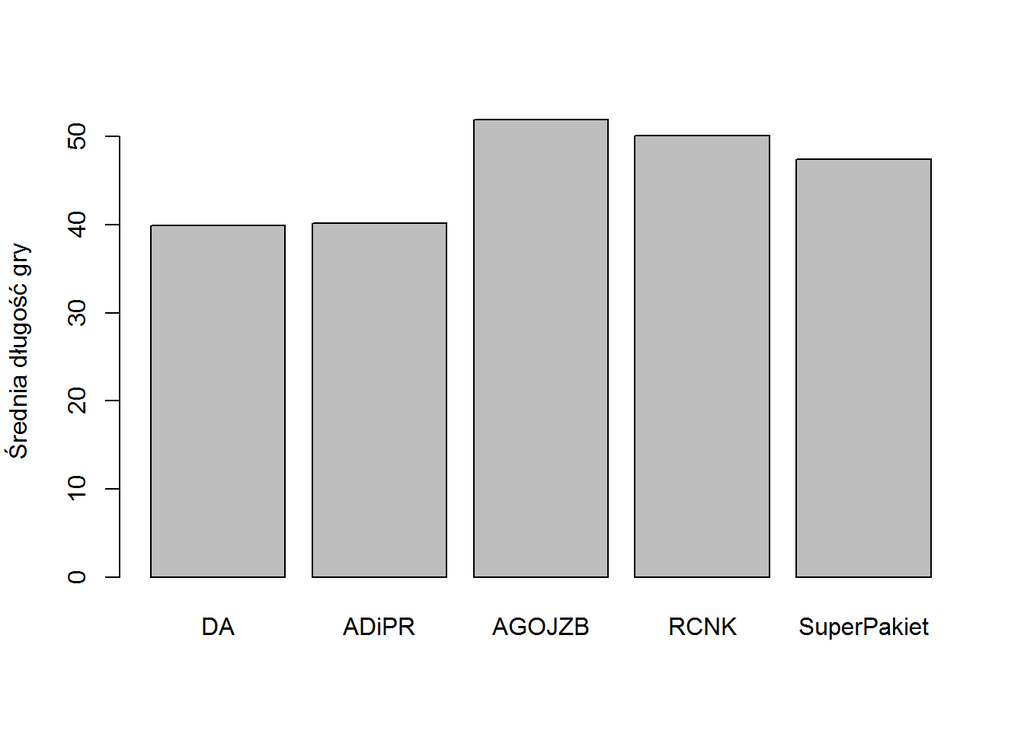

```r
names(x)<- c("DA","ADiPR","AGOJZB","RCNK","SuperPakiet")
barplot(x, ylab = "Średnia długość gry")
```

# strategia_maxrabbit na innych pakietach

Strategia `strategia_maxrabbit` działa również na innych pakietach.

```r
SuperFarmerAGOJZB::badaj_gre(strategia_maxrabbit, ilosc_wywolan=1000)
```

```
##  SuperFarmerAGOJZB::wywolaj_n_razy(ilosc_wywolan, strategia1, param, sprawdzanie)
##  Min.   : 12.00
##  1st Qu.: 26.00
##  Median : 35.00
##  Mean   : 39.47
##  3rd Qu.: 49.00
##  Max.   :138.00
```

```r
SuperFarmerADiPR::badaj_gre(strategia_maxrabbit, 1000)
```

```
##    Min. 1st Qu.  Median    Mean 3rd Qu.    Max.
##   10.00   25.00   33.00   39.19   47.00  145.00
```

```r
wektor <- SuperFarmerRCNK::badaj_gre(gra = SuperFarmerRCNK::gra, strategia_maxrabbit, ile_razy = 1000)
summary(wektor)
```

```
##    Min. 1st Qu.  Median    Mean 3rd Qu.    Max.
##   12.00   24.00   34.00   38.29   46.00  135.00
```

```r
SuperFarmer.SuperPakiet::badaj_gre(strategia_maxrabbit)[[1]]
```

```
##    Min. 1st Qu.  Median    Mean 3rd Qu.    Max.
##   10.00   24.00   33.00   38.31   47.00  175.00
```